# ASSESSMENT OF THE MEDITERRANEAN SWORDFISH STOCK BY MEANS OF ASSESSMENT FOR ALL INITIATIVE (a4a)

D. Mantopoulou-Palouka and G. Tserpes Hellenic Centre for Marine Research (HCMR), Greece

Assessments of the Mediterranean swordfish stock are performed using a statistical catch-at-age model, developed in the framework of Assessment for All (a4a) Initiative of the European Commission Joint Research Centre. Four runs are presented, including assumptions on natural mortality and the presence of discards in the catch. The model structural components are kept the same for each run. All of the assessment runs indicate that the stock is overexploited and the current fishing mortality rates are higher than those corresponding to maximum sustainable yield (MSY) levels.

# Introduction

In the present document, a statistical catch-at-age stock assessment model is being used to assess the status of the Mediterranean swordfish stock. The model was developed under the Assessment for All (a4a) initiative (Jardim et al., 2015) of the European Commission Joint Research Centre. The stock assessment framework is a non-linear catch-at-age model and is defined by submodels, which are the different parts that require structural assumptions. There are 5 submodels in operation: F-at-age, abundance indices catchability-at-age, recruitment, observation variance of catch and abundance indices-at-age and population’s age structure in the first year. Modelling assumptions include: Baranov’s equation for the catches, exponential decay of the population numbers and lognormality of catch and abundance indices errors. The a4a method utilizes catch-at-age data to derive estimates of historical population size and fishing mortality and, unlike XSA, model parameters estimated using by working forward in time while analyses do not require the assumption that removals from the fishery are known without error.

# Materials and Methods

Five standardized CPUE series extending up to the latest years were considered: Greek longliners (SCRS 2020/021), Moroccan longliners (SCRS 2020/026), Spanish longliners (SCRS 2020/043), Ligurian longliners (SCRS 2020/027) and Sicilian longliners (Tserpes et al. 2011). The standardized CPUE indices were not differentiated by age and were considered to be representative of the 2-4 age-group abundances. In the 2016 assessment it was assumed that fish first mature at age 3 (when 50% are mature) and are fully mature at older ages. Considering new information (ICCAT 2020), it was currently assumed 15% and 65% maturation at ages 2 and 3 respectively. Full maturity was considered from age 4 onward. Weights-at-age were derived from the mixture analysis and were consistent with the CAA. The F range (fbar) was set to ages 2-4, as in the previous assessments. Figure 1 illustrates the available CAA data by age and year while Figure 2 illustrates the available biomass indices by country.

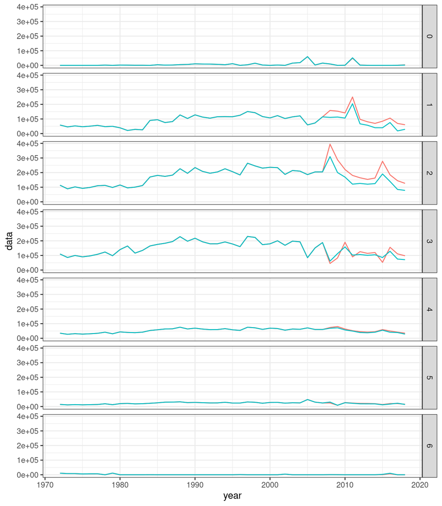

**Figure 1**. Time series of catch-at-age (blue line) and time series of catch-at-age including discards (red line).

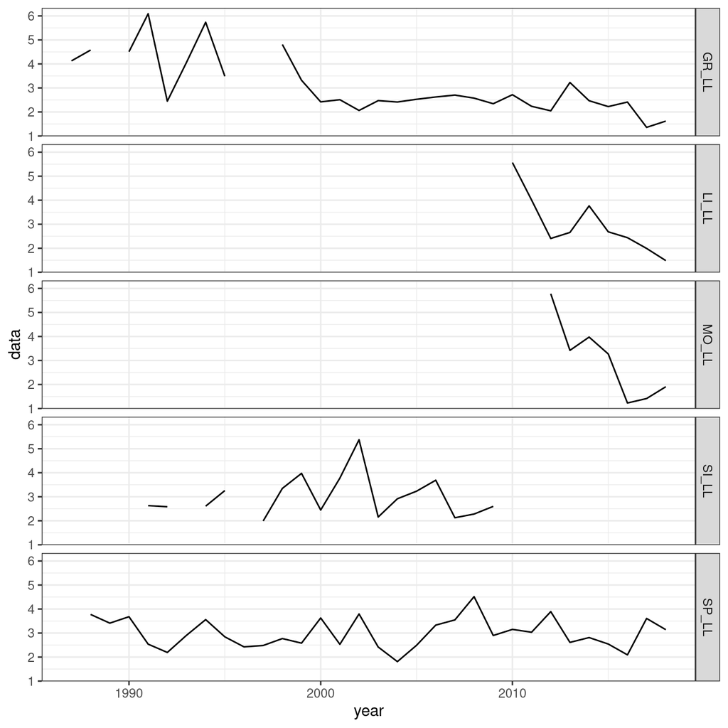

**Figure 2**. Time series of scaled standardized CPUE indexes by fleet: GR_LL = Greek longline, SP_LL = Spanish longline, MO_LL = Moroccan longline, LI_LL = Ligurian longline, SI_LL = Sicilian longline.

## Candidate Runs

Preliminary trials with the full CAA data set revealed unusual estimates for the earliest period. Given that, and the fact that the earliest CPUE series starts in 1987, it was decided to apply the candidate runs from 1985 onward, similarly to the previous assessments. The very few individuals present in age 6 suggested to use a plus group of 5, which improved a lot the stability of the different models tested as well as the residuals in catch-at-age numbers. Four different runs with the same a4a submodel setup are presented in this document. One with constant mortality vector M = 0.2, one with a differentiated natural mortality vector among ages using Lorenzen formula and the aforementioned different natural mortality vectors applied using a stock object with discards included. Various preliminary runs were conducted using different combination of the five available submodels. A final one was selected both in terms of residuals and model diagnostics as well as reasonable values for the estimated values of F, recruitment and SSB. The same final model setup is applied in all four different input stock objects.

For the fishing mortality $\mathbf{F}$, a separable submodel is being used, in which age and year effects are modeled by using thin plate regression splines (smoothers) provided by the package mgcv (Wood, 2003):
$$F: \quad \sim s(year, k = 17) + s(age, k = 3)$$
For the recruitment $\mathbf{R}$, a smoother through the years is being used:
$$R:\quad \sim s(year, k = 15)$$
For the catchability of the surveys $\mathbf{Q}$ five different models needed to be specified, one for each and while for the Greek, Spanish and Sicilian longline a constant model $(\sim 1)$ was assumed, for Moroccan and Ligurian longlines, a smoothing effect on the year was assumed, due to the trend in the residuals.
$$Q :
\begin{cases}
\sim 1, &\quad \text{Greek longline}\\
\sim 1, &\quad \text{Spanish longline}\\
\sim s(year, k=3), &\quad \text{Moroccan longline}\\
\sim s(year, k=3), &\quad \text{Ligurian longline}\\
\sim 1, &\quad \text{Sicilian longline}\\
\end{cases}$$
For the observation variance $\mathbf{\sigma^2}$ of the catches, the default spline through ages was selected and assumed no year effect, while the observation variances $\mathbf{\tau^{2}_{s}}$ of the five different tuning indices $s$, were all assumed constant throughout years.

$$\sigma^2 \sim s(age, k = 3), \quad\quad \tau^{2}_{s} \sim 1,\quad \text{for all } s$$
For the initial age structure $\mathbf{N_1}$ a smoother also was applied:
$$N : \quad\sim s(age, k =3)$$

# Results

The results for the four different runs are presented in the following sections. The constant natural mortality M = 0.2, (constant M), the Lorenzen natural mortality (Lorenzen M), the run with discards included and M assumed constant (Discards) and the run with discards included and Lorenzen natural mortality vector (Discards and Lorenzen M).

## candidate run assuming constant M

Model estimates for the candidate run assuming constant M are plotted in **Figures 3 - 4**.

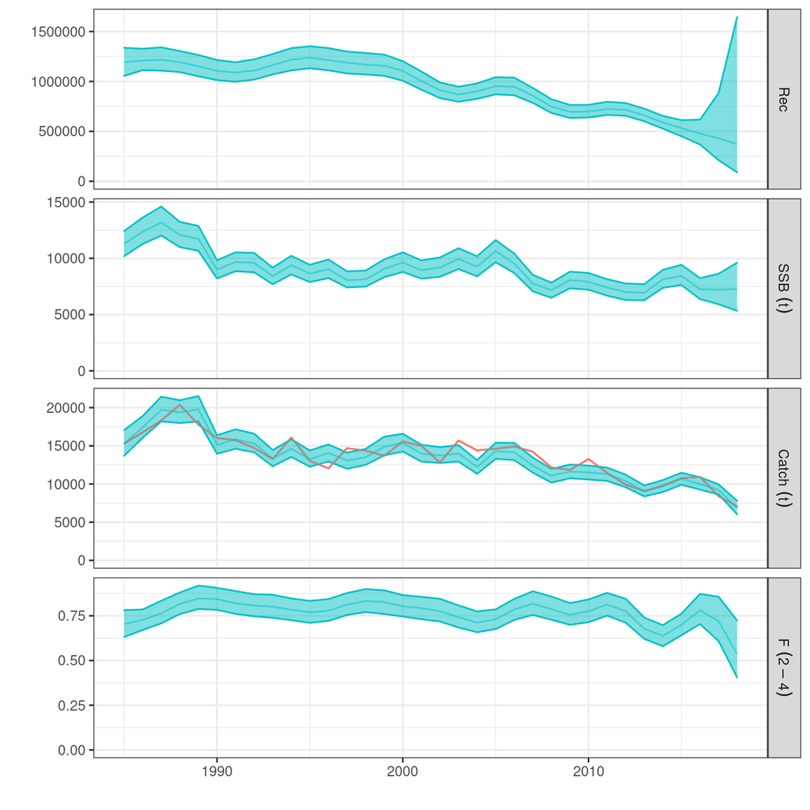

**Figure 3**. Estimated time series for the candidate run assuming constant M. Blue shaded areas represent the 80% estimated credible intervals, catch observations are presented in red line.

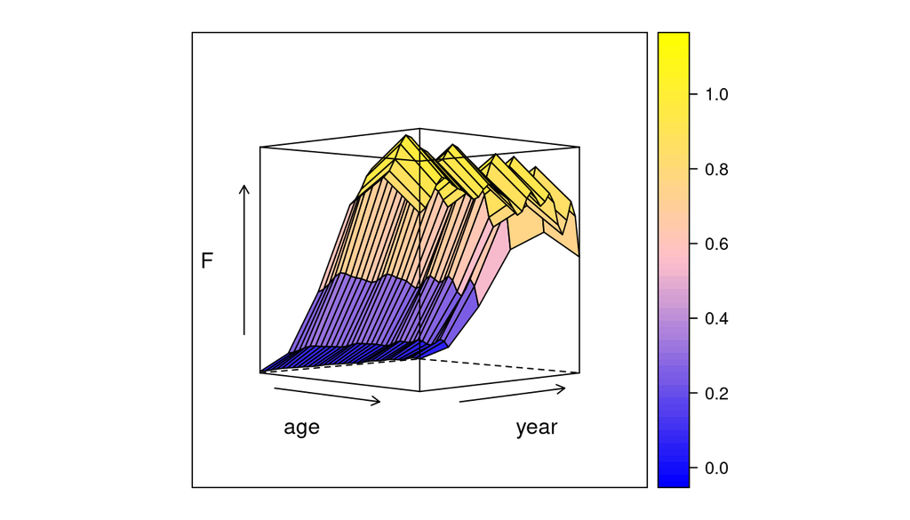

**Figure 4**. Estimates of harvest by age and year for the candidate run assuming constant M.

### Diagnostics for candidate run assuming constant M

Diagnostics plots for the candidate run assuming constant M are shown in **Figures 5 - 8**

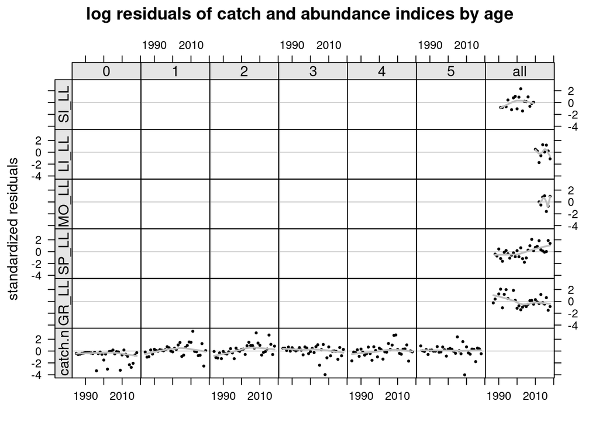

**Figure 5**. Standardized residuals for biomass indices and catch numbers for candidate run assuming constant M. Each panel is coded by age class, dots represent standardized residuals and lines a simple smoother.

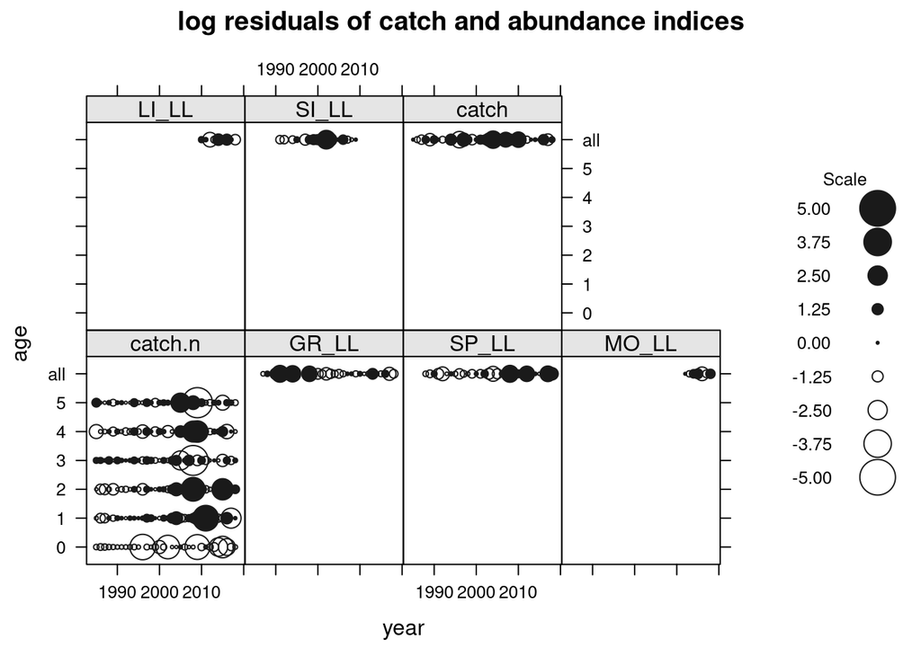

**Figure 6**. Bubble plot of standardized residuals for biomass indices and for catch numbers for candidate run assuming constant M.

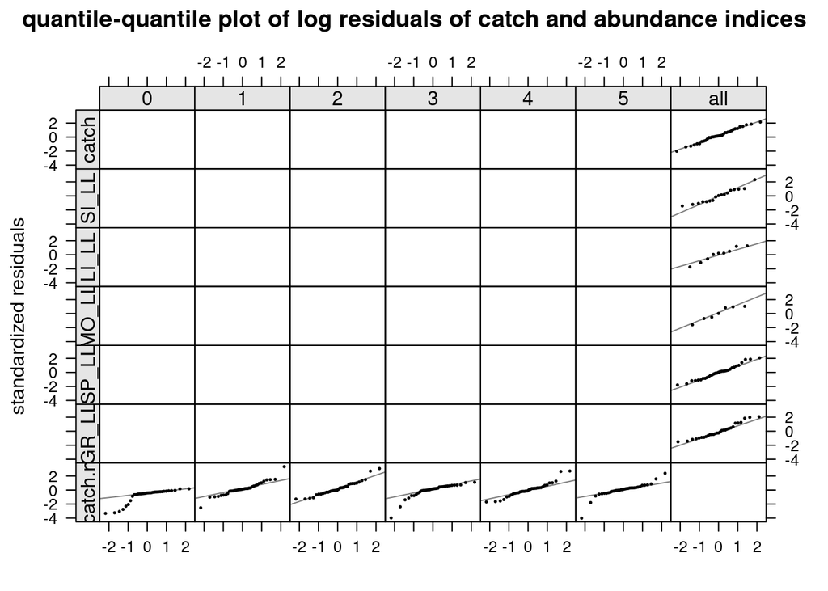

**Figure 7**. Quantile-quantile plot of standardized residuals for biomass indices and catch numbers for the candidate run assuming constant M. Each panel is coded by age class, dots represent standardized residuals and lines the normal distribution quantiles.

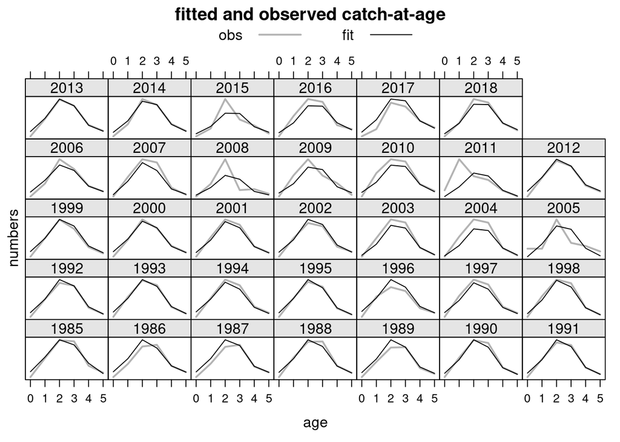

**Figure 8**. Observed against fitted values by year and age for the candidate run assuming constant M.

### Retrospective plot for candidate run assuming constant M

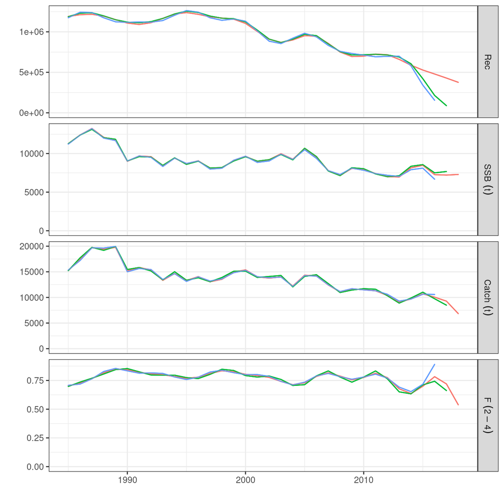

**Figure 9**. Retrospective plot for the candidate run assuming constant M.

## Candidate run assuming Lorenzen M vector

Model estimates for the candidate run assuming Lorenzen M vector are plotted in **Figures 10 - 11**.

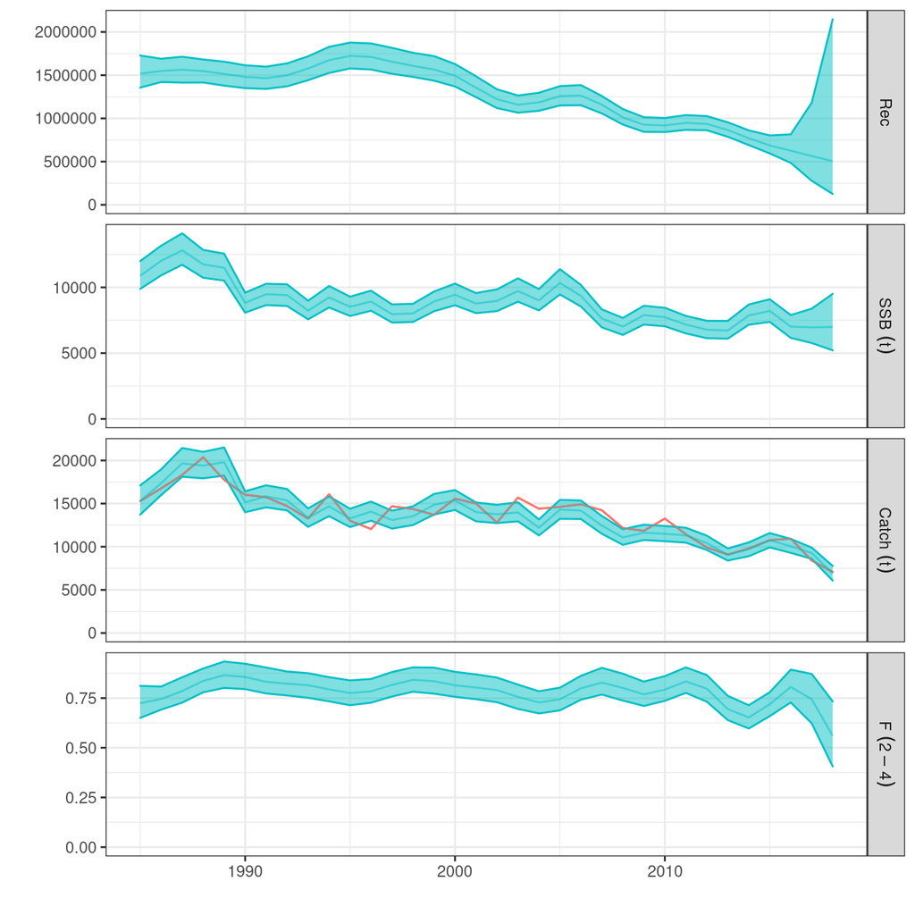

**Figure 10**. Estimated time series for the candidate run assuming Lorenzen M vector. Blue shaded areas represent the 80% estimated credible intervals, catch observations are presented in red line.

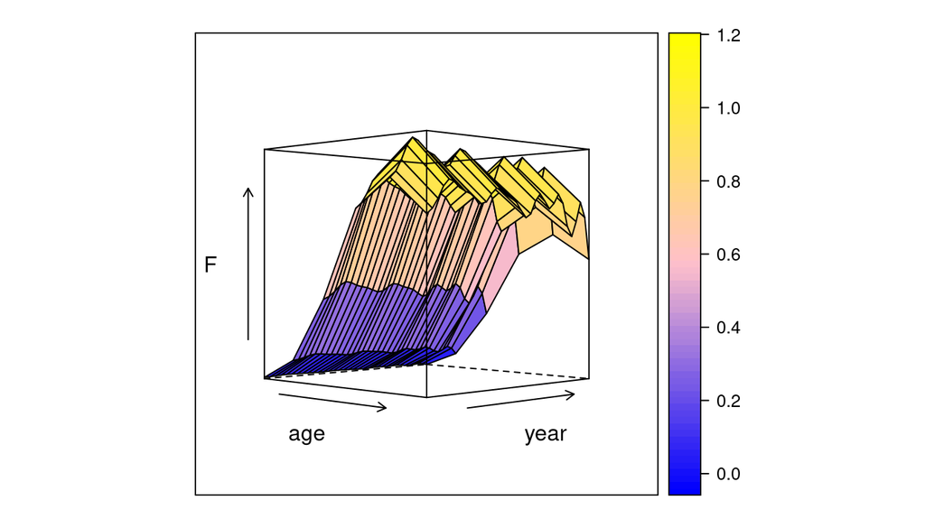

**Figure 11**. Estimates of harvest by age and year for the candidate run assuming Lorenzen M vector.

### Diagnostics for candidate run assuming Lorenzen M vector

Diagnostics plots for the candidate run assuming Lorenzen M vector are shown in **Figures 12 - 15**

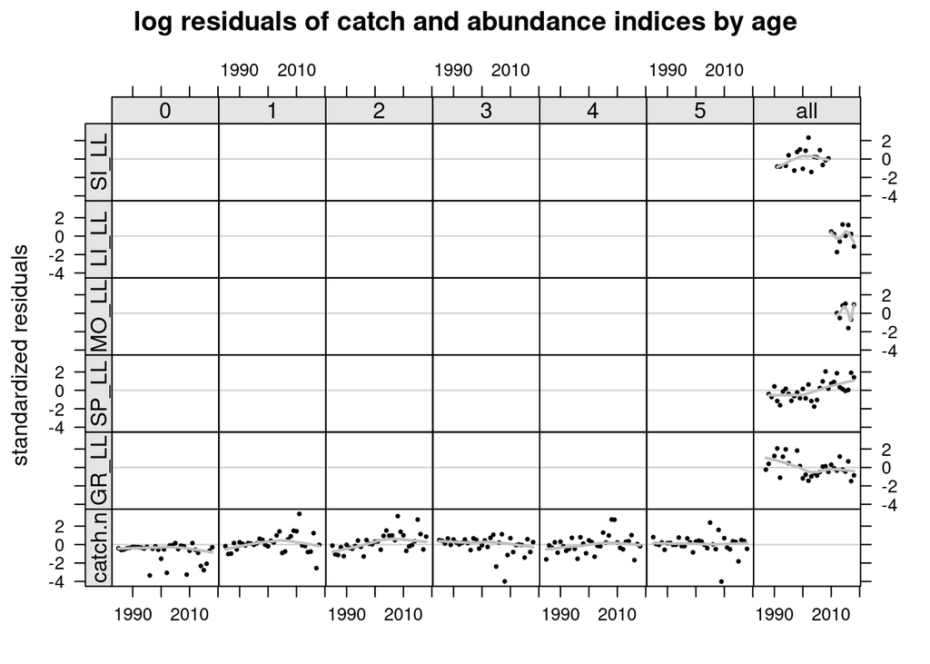

**Figure 12**. Standardized residuals for biomass indices and catch numbers for the candidate run assuming Lorenzen M vector. Each panel is coded by age class, dots represent standardized residuals and lines a simple smoother.

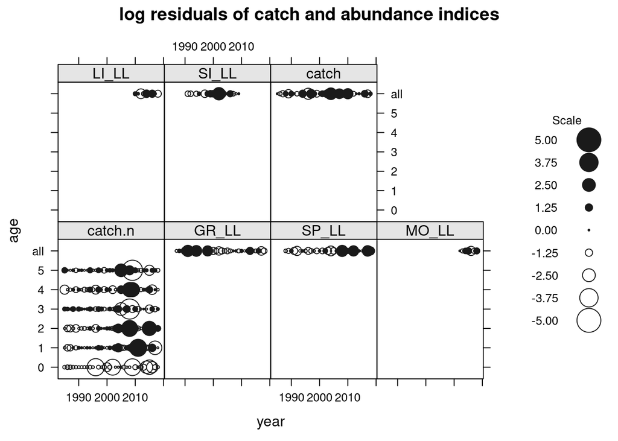

**Figure 13**. Bubble plot of standardized residuals for biomass indices and for catch numbers for the candidate run assuming Lorenzen M vector.

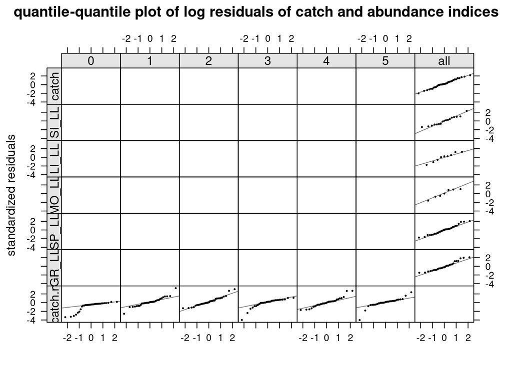

**Figure 14**. Quantile-quantile plot of standardized residuals for biomass indices and catch numbers for the candidate run assuming Lorenzen M vector. Each panel is coded by age class, dots represent standardized residuals and lines the normal distribution quantiles.

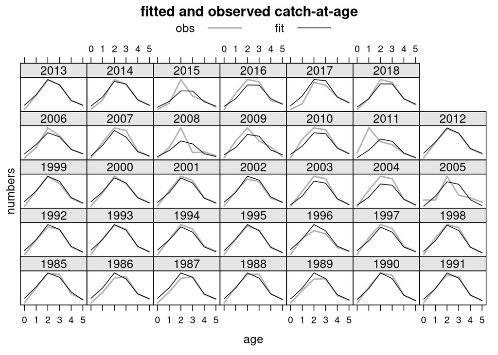

**Figure 15**. Observed against fitted values by year and age for the candidate run assuming Lorenzen M vector.

### Retrospective plot for candidate run assuming Lorenzen M vector

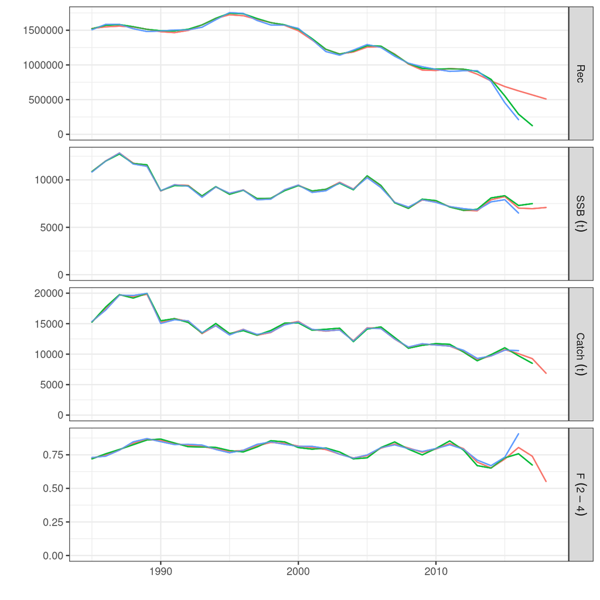

**Figure 16**. Retrospective plot for the candidate run assuming Lorenzen M vector.

## Discard run assuming constant M

Model estimates for the discard run assuming constant M are plotted in **Figures 17 - 18**.

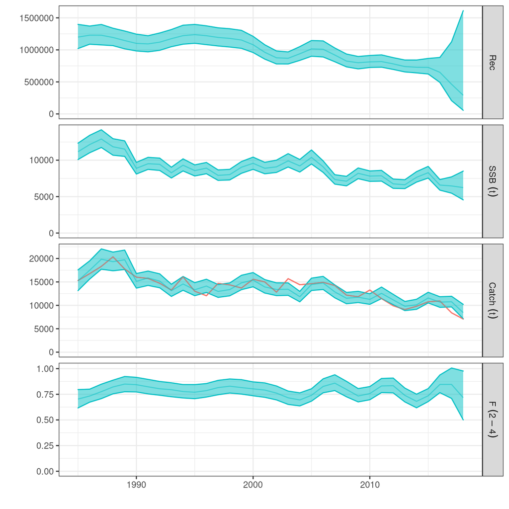

**Figure 17**. Estimated time series for the discard run assuming constant M. Blue shaded areas represent the 80% estimated credible intervals, catch observations are presented in red line.

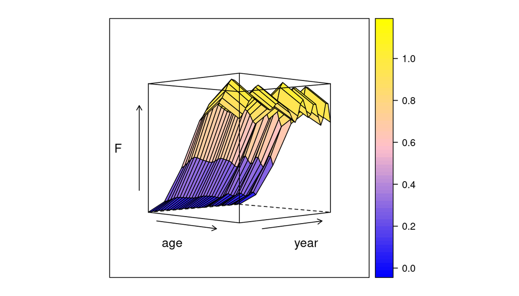

**Figure 18**. Estimates of harvest by age and year for the discard run assuming constant M.

### Diagnostics for Discards candidate run assuming constant M

Diagnostics plots for the discard run assuming constant M are shown in **Figures 19 - 22**

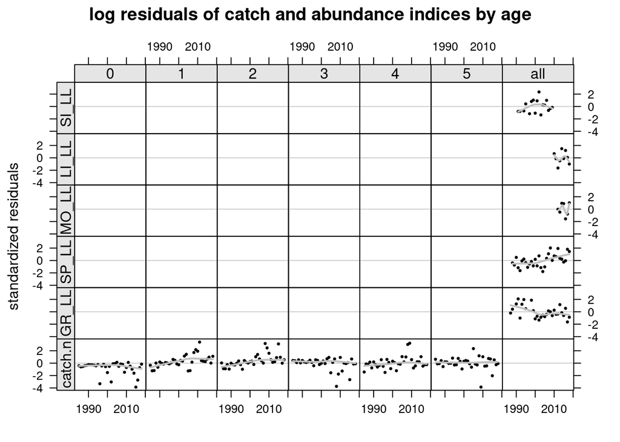

**Figure 19**. Standardized residuals for biomass indices and catch numbers for the discard run assuming constant M. Each panel is coded by age class, dots represent standardized residuals and lines a simple smoother.

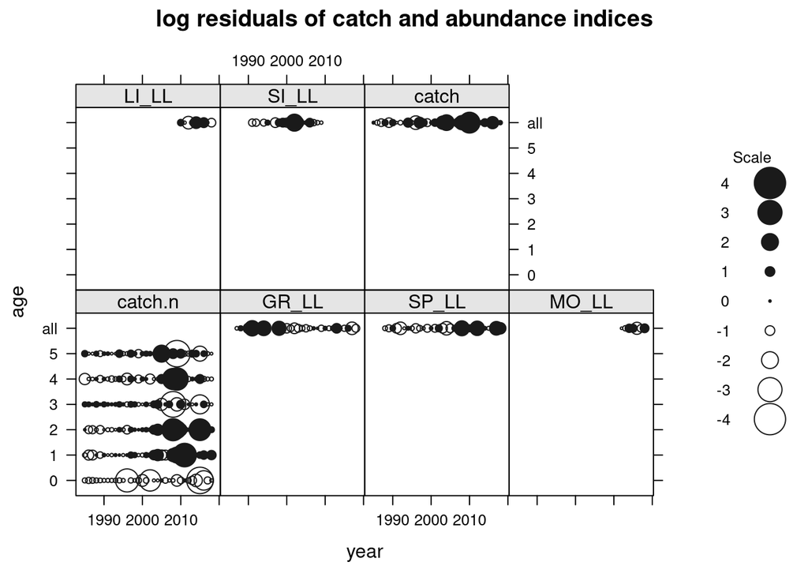

**Figure 20**. Bubble plot of standardized residuals for biomass indices and for catch numbers for the discard run assuming constant M.

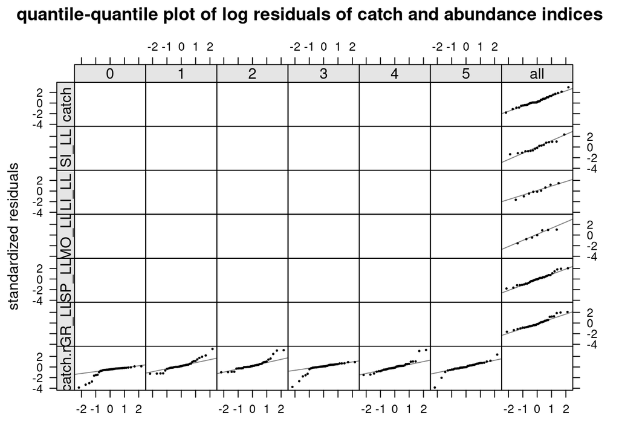

**Figure 21**. Quantile-quantile plot of standardized residuals for biomass indices and catch numbers for the discard run assuming constant M. Each panel is coded by age class, dots represent standardized residuals and lines the normal distribution quantiles.

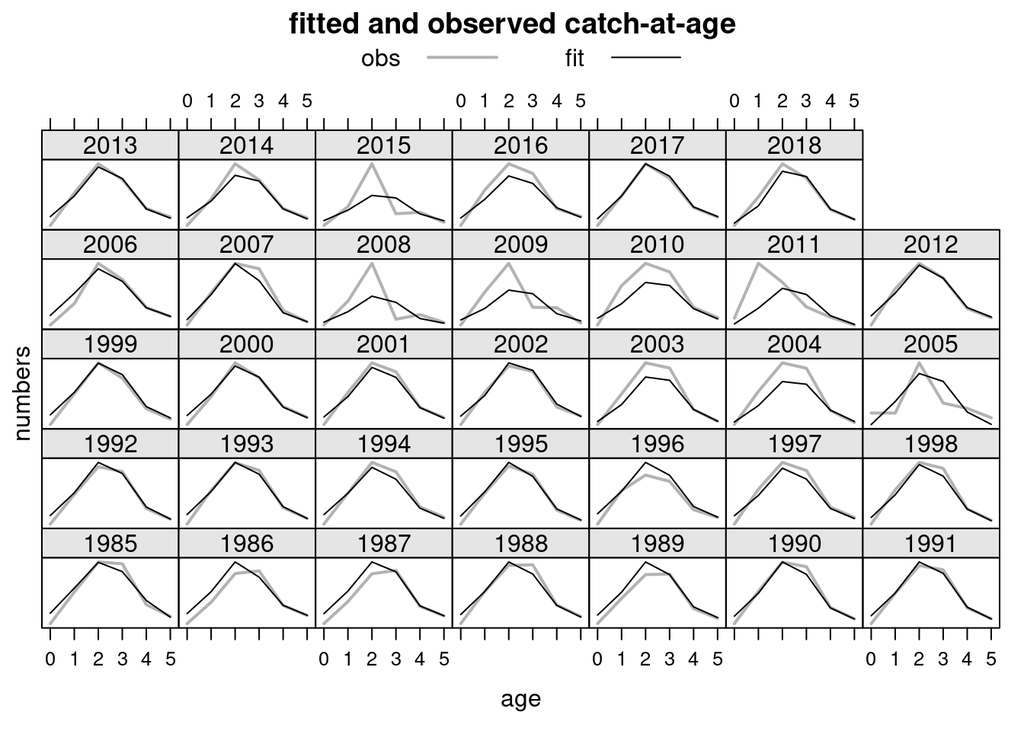

**Figure 22**. Observed against fitted values by year and age for the discard run assuming constant M.

### Retrospective plot for the discard run assuming constant M

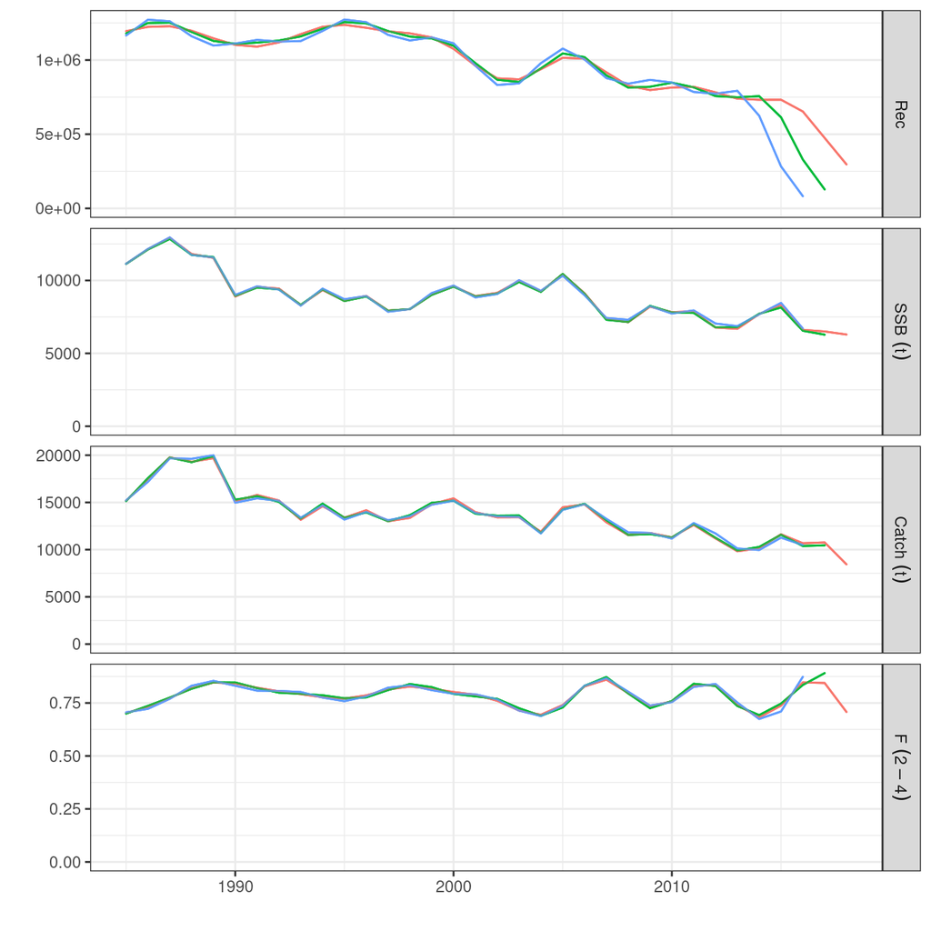

**Figure 23**. Retrospective plot for the discard run assuming constant M.

## Discard run assuming Lorenzen M vector

Model estimates for the discard run assuming Lorenzen M are plotted in **Figures 24 - 25**.

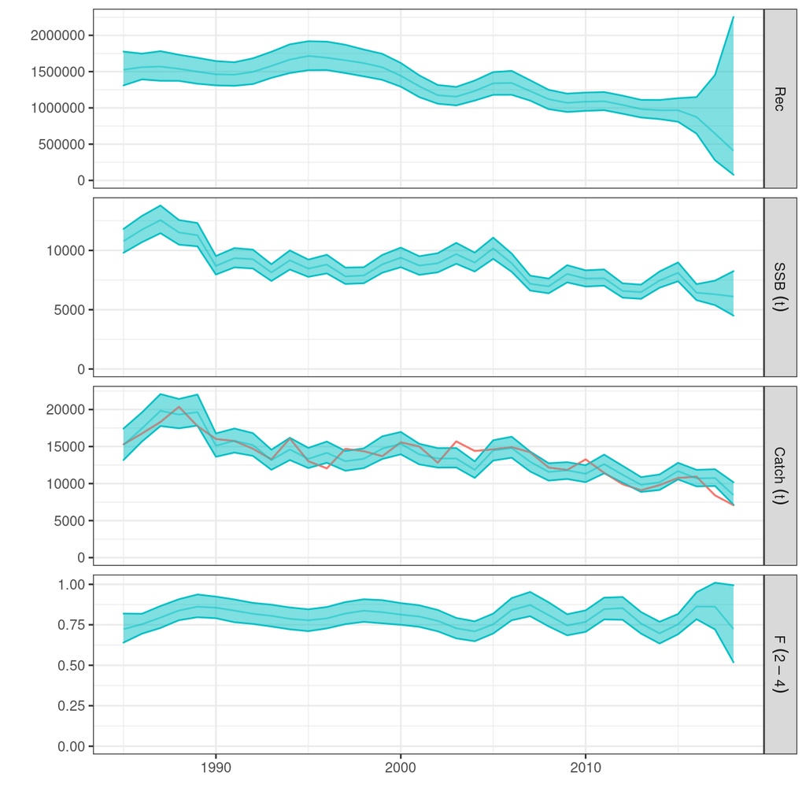

**Figure 24**. Estimated time series for the discard run assuming Lorenzen M vector. Blue shaded areas represent the 80% estimated credible intervals, catch observations are presented in red line.

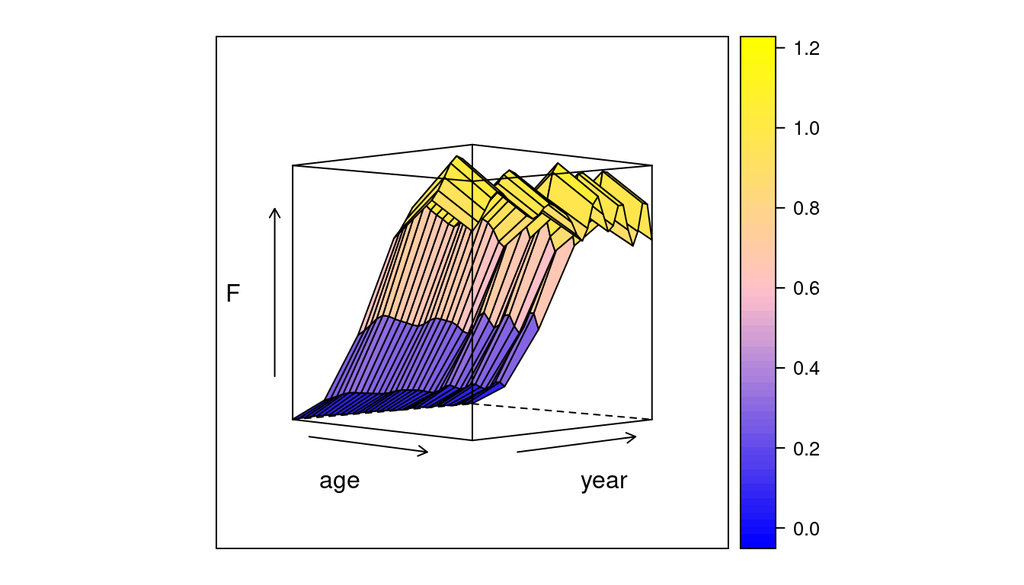

**Figure 25**. Estimates of harvest by age and year for the discard run assuming Lorenzen M vector.

### Diagnostics for Discards with Lorenzen M candidate Run

Diagnostics plots for the discard run assuming Lorenzen M vector are shown in **Figures 26 - 29**

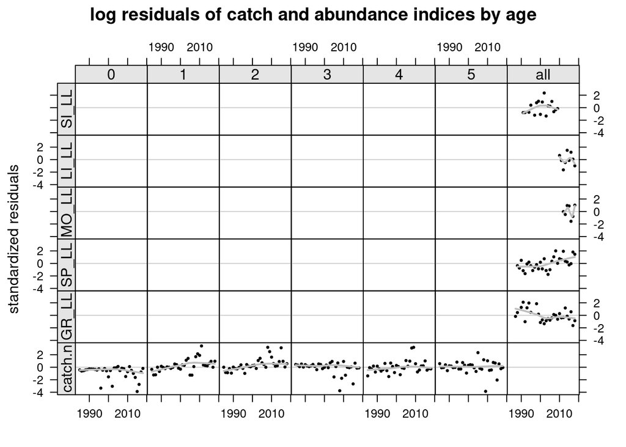

**Figure 26**. Standardized residuals for biomass indices and catch numbers for the discard run assuming Lorenzen M vector. Each panel is coded by age class, dots represent standardized residuals and lines a simple smoother.

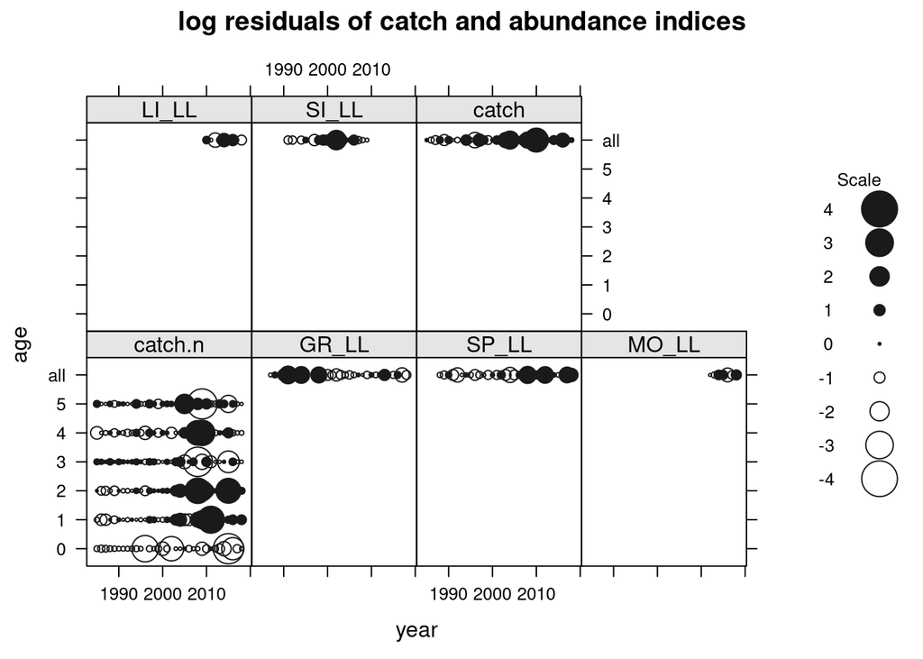

**Figure 27**. Bubble plot of standardized residuals for biomass indices and for catch numbers for the discard run assuming Lorenzen M vector.

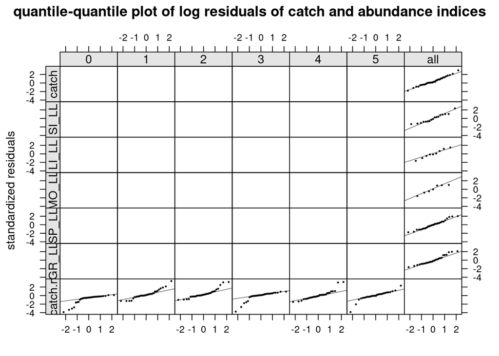

**Figure 28**. Quantile-quantile plot of standardized residuals for biomass indices and catch numbers for the discard run assuming Lorenzen M vector. Each panel is coded by age class, dots represent standardized residuals and lines the normal distribution quantiles.

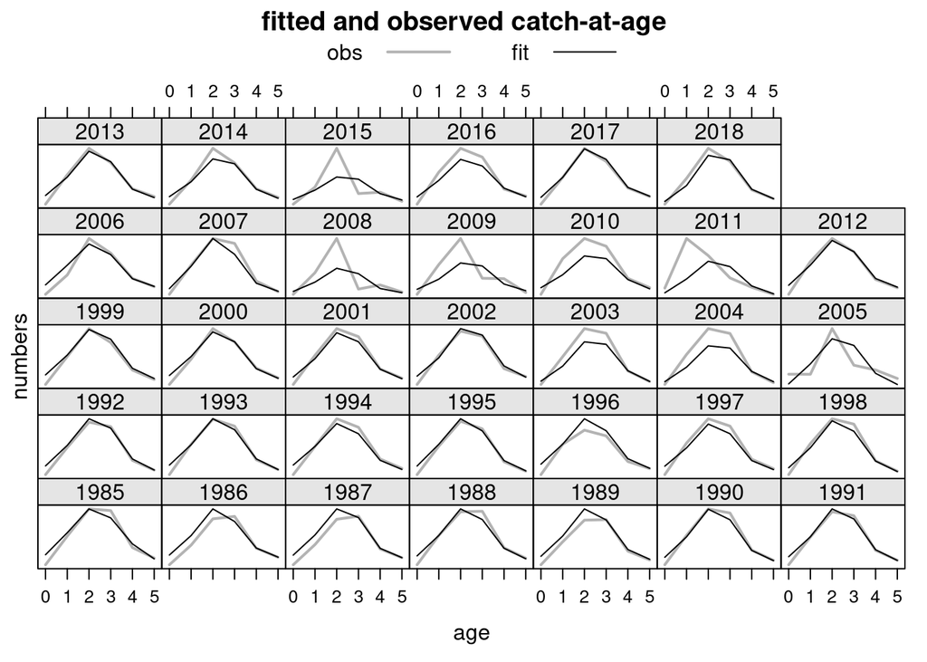

**Figure 29**. Observed against fitted values by year and age for the discard run assuming Lorenzen M vector.

### Retrospective plot for the discard run assuming Lorenzen M vector

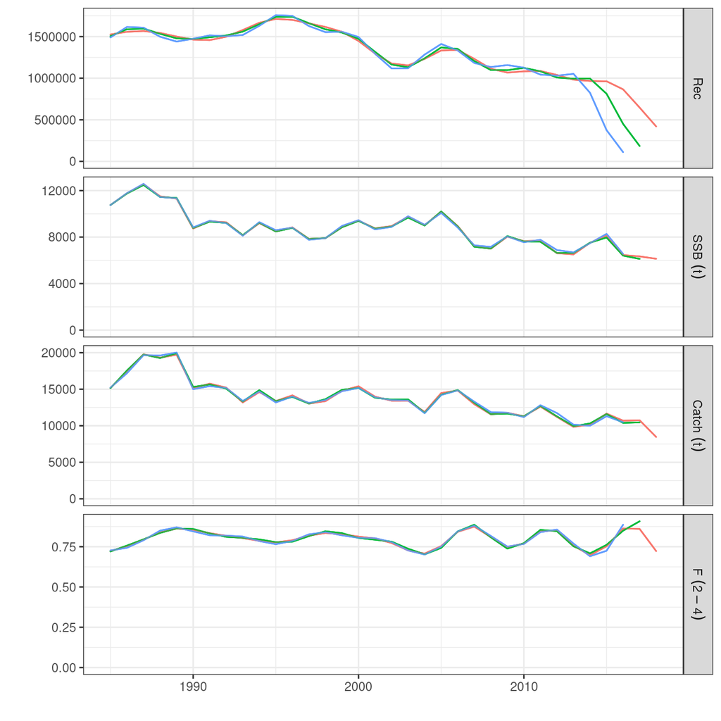

**Figure 30**. Retrospective plot for the discard run assuming Lorenzen M vector.

## Comparison

Estimated time series for the four different runs are presented in the **Figure 31**

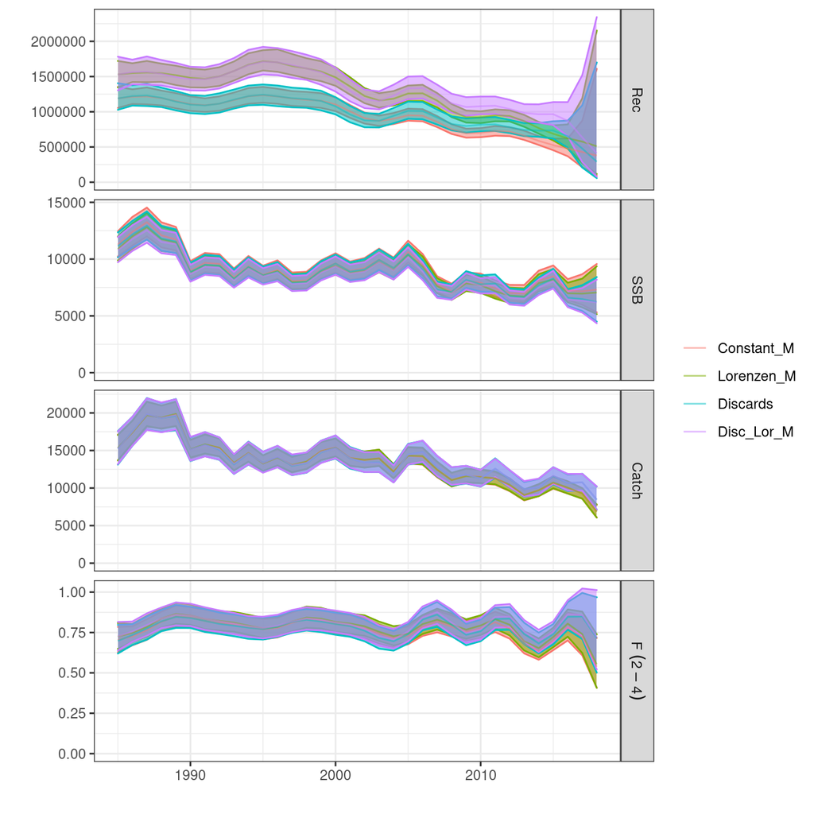

**Table 1**. GCV scores for the four different runs:

| score | Constant_M | Lorenzen_M | Discards | Discards_Lorenzen |
| --- | --- | --- | --- | --- |
| GCV | 8.278037 | 8.424394 | 8.443392 | 8.582501 |